# GLM - Regresión Logística

Autor

Natalia Madrueño Sierro - Carmen Lancho Martín

Fecha

martes, 14 de abril de 2026

# Introducción a los Modelos Lineales Generalizados (GLMs)

Los modelos lineales generalizados son una extensión de los modelo de regresión lineal ($E(Y)=\beta_0 + \beta_1 X_1 + \dots \beta_p X_p$, siendo $p$ el número de variables dependientes), diseñados para cubrir las limitaciones del modelo de regresión lineal (la variable respuesta $Y$ puede no ser normal, no hay homogeneidad de varianzas).

En los modelos lineales generalizados, se usa una transformación $g(\cdot)$ de $E(Y)=\mu$ que permita considerar una relación lineal con las variables explicativas:

$$g(\mu) = \beta_0 + \beta_1 X_1 + \dots \beta_p X_p$$

De este modo, un modelo lineal generalizado está compuesto por:

1. La variable dependiente $Y$ cuya distribución pertenece a la familia exponencial (e.g., Binomial, Poisson, Normal).
2. Las variables explicativas $X_1,\cdots, X_p$ (serán variables dummy para los niveles de un factor)
3. Los coeficientes $\beta_0,\beta_1\cdots,\beta_p$ asociados a dichas variables explicativas y al intercepto.
4. Una función $g(\cdot)$, llamada función link o de enlace, que conecta la esperanza de la variable respuesta con el predictor lineal. Esta función $g$ es monótona y diferenciable.

Nótese que el modelo de regresión lineal no es más que un caso particular de los GLMs con $Y \sim Normal$ y $g(\mu)=E(\mu)$.

Algunos ejemplos de GLMs son:

- Datos con conteos de eventos (distribución Poisson).
- Datos con proporciones o eventos binarios (distribución Binomial).

En este documento, nos centraremos en la regresión logística, es decir, en el caso en el que el target o variable objetivo es binaria $Y \in \{0,1\}$.

# GLMs para variables binarias

Cuando la variable respuesta es binaria ($Y \in \{0,1\}$), lo que se modela es la probabilidad de éxito ($P(Y=1)$):

$$\text{Probabilidad de éxito }\ \ \ P(Y_i = 1) = \pi_i$$

$$\text{Probabilidad de fracaso }\ \ \ P(Y_i = 0) = 1 - \pi_i$$
con $\pi_i \in [0,1]$.

Esta probabilidad de éxito se va a modelar en función de las covariables ($X_1,\cdots,X_p$) observadas. Sin embargo, en este caso, un modelo lineal estándar
$$\pi_i = \beta_0 + \beta_1 X_{i1} + \dots \beta_p X_{ip}$$
no resultaría adecuado puesto que dicha combinación lineal puede dar valores fuera del rango $[0,1]$.

¿Cómo solucionamos esta situación? Mediante una transformación $g(\cdot)$ que cumpla las condiciones dichas anteriormente y que pase de las probabilidades $\pi_i$ que toman valor en $[0,1]$ a $g(\pi)$ que tome valores en la recta real.

En particular, existen 3 funciones link distintas para esta situación:

- Logit:
  $$g(\pi_i)= logit(\pi_i)=\log \left( \dfrac{\pi_i}{1-\pi_i} \right)$$
- Probit:
  $$g(\pi_i)= probit(\pi_i)= \phi^{-1} (\pi_i)$$
  siendo $\phi$ la función de distribución de la Normal estándar.
- cloglog:
  $$g(\pi_i)= cloglog(\pi_i)= \log(- \log(1- \pi_i))$$

Despejando $\pi$ en cada caso obtenemos:

- Logit:
  $$\pi= \dfrac{\exp(\mathbf{X}^{t}\mathbf{\beta})}{1+\exp(\mathbf{X}^{t}\mathbf{\beta})} = \dfrac{1}{1+\exp(-\mathbf{X}^{t}\mathbf{\beta})}$$
- Probit:
  $$\pi = \phi(\mathbf{X}^{t}\mathbf{\beta})$$
- cloglog:
  $$\pi = 1-\exp(-\exp(\mathbf{X}^{t}\mathbf{\beta}))$$

### Comparación gráfica de las funciones de enlace

Vamos a graficar las 3 funciones de enlace (y sus inversas) para poder compararlas mejor.

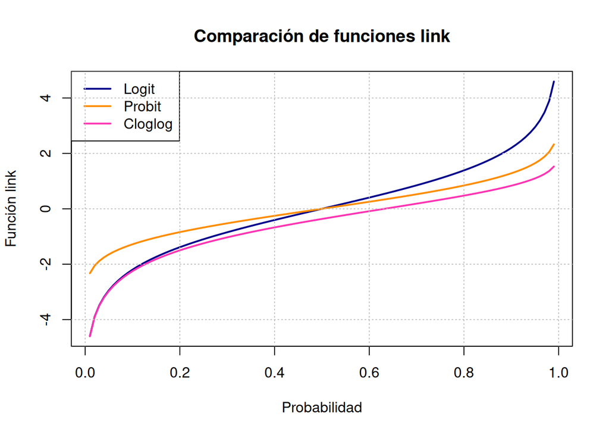

```r
# Probabilidades
prob <- seq(0.01, 0.99, length.out = 100)
# Funciones de enlace
logit <- log(prob / (1 - prob))
probit <- qnorm(prob)
cloglog <- log(-log(1 - prob))

plot(prob, logit, type = "l", col = "darkblue",lwd=2,
     ylab = "Función link", xlab = "Probabilidad", main = "Comparación de funciones link")
lines(prob, probit, col = "darkorange",lwd=2)
lines(prob, cloglog, col = "maroon1",lwd=2)
legend("topleft", legend = c("Logit", "Probit", "Cloglog"),
       col = c("darkblue", "darkorange", "maroon1"), lty = 1,lwd=2)

# Cuadrícula
grid(col = "gray", lty = 3)
```

Con las inversas (no es más que girar el gráfico):

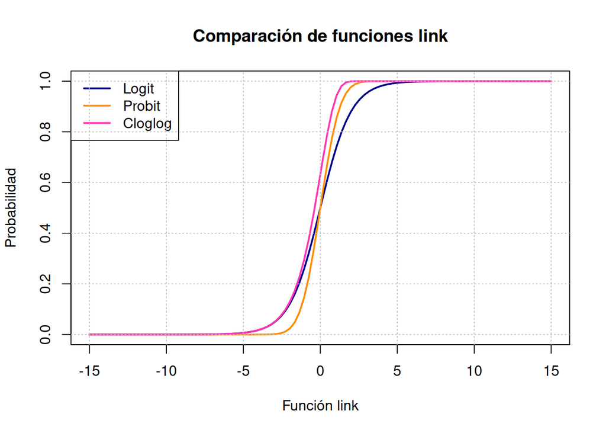

```r
# valores en la recta real
x <- seq(-15, 15, length.out = 100)

# Funciones de enlace
logit <- 1 / (1 + exp(-x))
probit <- pnorm(x)
cloglog <- 1 - exp(-exp(x))


plot(x, logit, type = "l", col = "darkblue",lwd=2,
     ylab = "Probabilidad", xlab = "Función link", main = "Comparación de funciones link")
lines(x, probit, col = "darkorange",lwd=2)
lines(x, cloglog, col = "maroon1",lwd=2)
legend("topleft", legend = c("Logit", "Probit", "Cloglog"),
       col = c("darkblue", "darkorange", "maroon1"), lty = 1,lwd=2)

# Cuadrícula
grid(col = "gray", lty = 3)
```

# Ejemplo en R de regresión logística con los datos kyphosis

Comenzamos cargando los datos kyphosis de la librería rpart:

```r
library(rpart)
library(ggplot2)
data(kyphosis)
```

El conjunto de datos kyphosis contiene información sobre 81 pacientes que fueron sometidos a una operación para corregir la cifosis. La cifosis es una curvatura convexa anormalmente excesiva de la columna vertebral. Las variables son:

- kyphosis: variable binaria que toma los valores present/absent indicando si había cifosis tras la operación
- age: edad en meses
- number: número de vertebras involucradas
- start: el número de la primera vértebra (superior) operada

El objetivo es predecir si un paciente desarrollará una complicación postoperatoria de cifosis o no en función de las 3 variables disponibles.

Les echamos un primer vistazo:

```r
head(kyphosis)
```

```
  Kyphosis Age Number Start
1   absent  71      3     5
2   absent 158      3    14
3  present 128      4     5
4   absent   2      5     1
5   absent   1      4    15
6   absent   1      2    16
```

Veamos cómo está guardada cada variable (numérica, factor, etc):

```r
str(kyphosis)
```

```
'data.frame':   81 obs. of  4 variables:
 $ Kyphosis: Factor w/ 2 levels "absent","present": 1 1 2 1 1 1 1 1 1 2 ...
 $ Age     : int  71 158 128 2 1 1 61 37 113 59 ...
 $ Number  : int  3 3 4 5 4 2 2 3 2 6 ...
 $ Start   : int  5 14 5 1 15 16 17 16 16 12 ...
```

La variable kyphosis está correctamente guardada como un factor y el resto como numéricas. Con el siguiente código vemos que 0 es absent y 1 es present. De no ser así, deberíamos cambiar el orden para asegurar, a la hora de hacer el glm, que modelamos la probabilidad de $Y=1$ (present).

```r
levels(kyphosis$Kyphosis)
```

```
[1] "absent"  "present"
```

Hagamos un breve resumen inicial:

```r
summary(kyphosis)
```

```
    Kyphosis       Age             Number           Start
 absent :64   Min.   :  1.00   Min.   : 2.000   Min.   : 1.00
 present:17   1st Qu.: 26.00   1st Qu.: 3.000   1st Qu.: 9.00
              Median : 87.00   Median : 4.000   Median :13.00
              Mean   : 83.65   Mean   : 4.049   Mean   :11.49
              3rd Qu.:130.00   3rd Qu.: 5.000   3rd Qu.:16.00
              Max.   :206.00   Max.   :10.000   Max.   :18.00
```

Como en cualquier estudio con datos, lo primero es realizar un análisis exploratorio de los datos.

### Análisis exploratorio de kyphosis

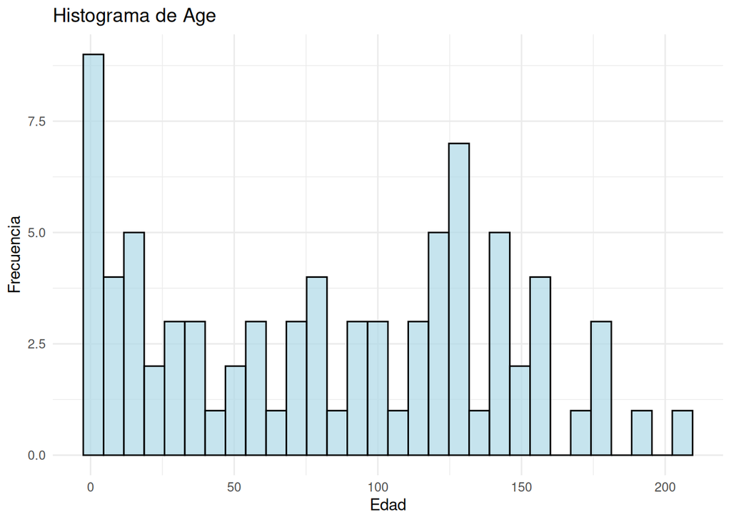

```r
ggplot(kyphosis, aes(x = Age)) +
  geom_histogram( fill = "lightblue", color = "black", alpha = 0.7) +
  labs(title = "Histograma de Age", x = "Edad", y = "Frecuencia") +
  theme_minimal()
```

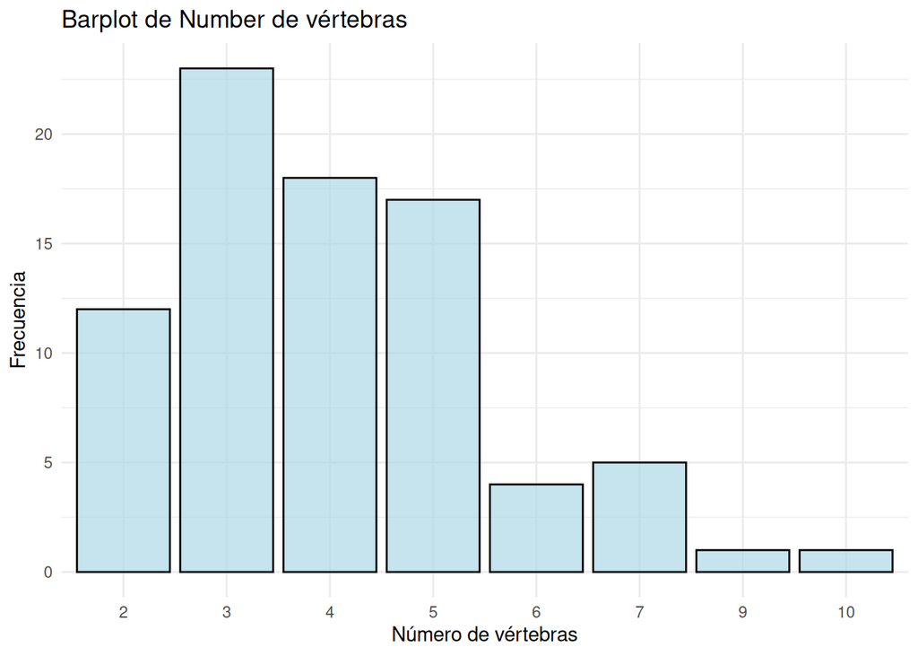

```r
ggplot(kyphosis, aes(x = as.factor(Number))) +
  geom_bar(fill = "lightblue", color = "black", alpha = 0.7) +
  labs(title = "Barplot de Number de vértebras", x = "Número de vértebras", y = "Frecuencia") +
  theme_minimal()
```

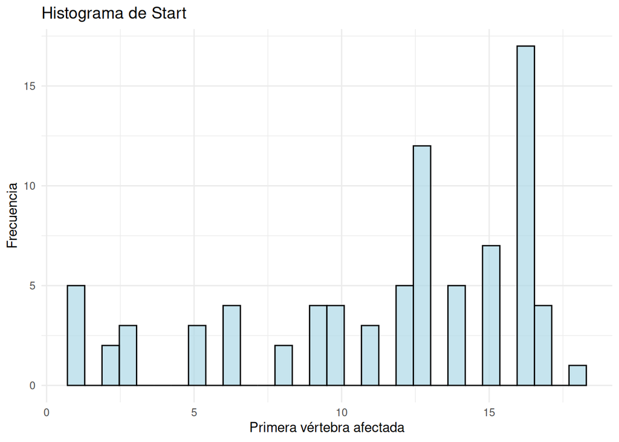

```r
ggplot(kyphosis, aes(x = Start)) +
  geom_histogram(fill = "lightblue", color = "black", alpha = 0.7) +
  labs(title = "Histograma de Start", x = "Primera vértebra afectada", y = "Frecuencia") +
  theme_minimal()
```

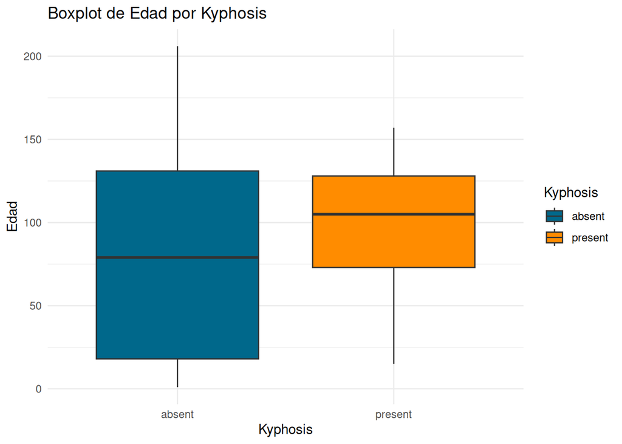

```r
ggplot(kyphosis, aes(x = Kyphosis, y = Age, fill = Kyphosis)) +
  geom_boxplot() +
  labs(title = "Boxplot de Edad por Kyphosis", x = "Kyphosis", y = "Edad") +
  theme_minimal() +
  scale_fill_manual(values = c("deepskyblue4", "darkorange"))
```

```r
# Prueba de Mann-Whitney
age_test <- wilcox.test(Age ~ Kyphosis, data = kyphosis)
print(age_test)
```

```
    Wilcoxon rank sum test with continuity correction

data:  Age by Kyphosis
W = 446.5, p-value = 0.2605
alternative hypothesis: true location shift is not equal to 0
```

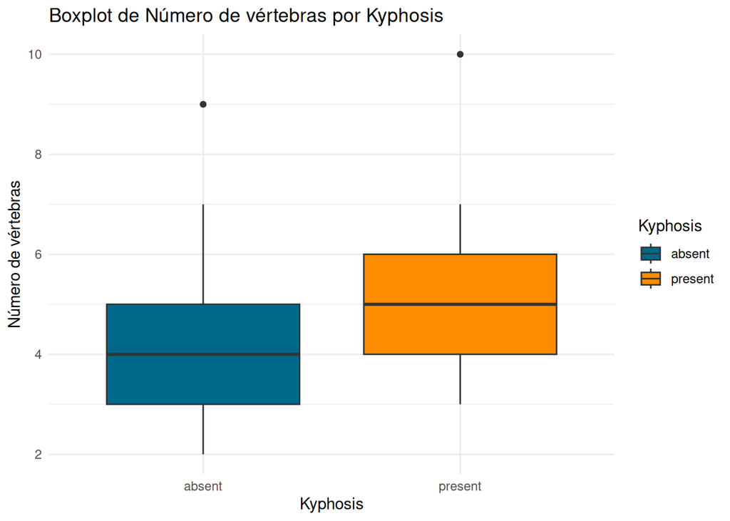

```r
ggplot(kyphosis, aes(x = Kyphosis, y = Number, fill = Kyphosis)) +
  geom_boxplot() +
  labs(title = "Boxplot de Número de vértebras por Kyphosis", x = "Kyphosis", y = "Número de vértebras") +
  theme_minimal() +
  scale_fill_manual(values = c("deepskyblue4", "darkorange"))
```

```r
# Prueba de Mann-Whitney
number_test <- wilcox.test(Number ~ Kyphosis, data = kyphosis)
print(number_test)
```

```
    Wilcoxon rank sum test with continuity correction

data:  Number by Kyphosis
W = 289, p-value = 0.002504
alternative hypothesis: true location shift is not equal to 0
```

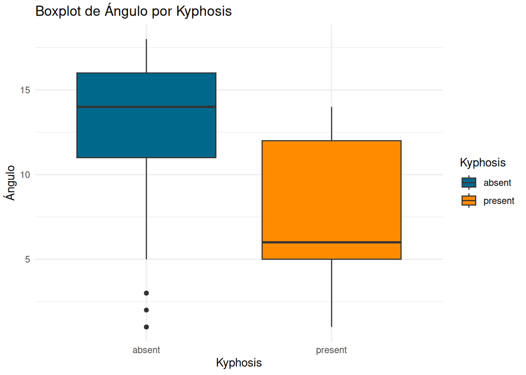

```r
ggplot(kyphosis, aes(x = Kyphosis, y = Start, fill = Kyphosis)) +
  geom_boxplot() +
  labs(title = "Boxplot de Ángulo por Kyphosis", x = "Kyphosis", y = "Ángulo") +
  theme_minimal() +
  scale_fill_manual(values =  c("deepskyblue4", "darkorange"))
```

```r
# Prueba de Mann-Whitney
start_test <- wilcox.test(Start ~ Kyphosis, data = kyphosis)
print(start_test)
```

```
    Wilcoxon rank sum test with continuity correction

data:  Start by Kyphosis
W = 896, p-value = 4.023e-05
alternative hypothesis: true location shift is not equal to 0
```

### Modelo de regresión logística

Comenzamos ajustando un modelo de regresión logística con todas las variables y usando la función de enlace logit. Tenemos que aclarar también cuál es la distribución de la variables respuesta. En este caso es binomial. Podéis encontrar más información en la [ayuda de R](https://www.rdocumentation.org/packages/stats/versions/3.6.2/topics/family).

```r
glm_fit=glm(Kyphosis~., family=binomial("logit"),data=kyphosis)
# Kyphosis~. es lo mismo que Kyphosis~Age+Number+Start
summary(glm_fit)
```

```
Call:
glm(formula = Kyphosis ~ ., family = binomial("logit"), data = kyphosis)

Coefficients:
             Estimate Std. Error z value Pr(>|z|)
(Intercept) -2.036934   1.449575  -1.405  0.15996
Age          0.010930   0.006446   1.696  0.08996 .
Number       0.410601   0.224861   1.826  0.06785 .
Start       -0.206510   0.067699  -3.050  0.00229 **
---
Signif. codes:  0 '***' 0.001 '**' 0.01 '*' 0.05 '.' 0.1 ' ' 1

(Dispersion parameter for binomial family taken to be 1)

    Null deviance: 83.234  on 80  degrees of freedom
Residual deviance: 61.380  on 77  degrees of freedom
AIC: 69.38

Number of Fisher Scoring iterations: 5
```

¿Qué significa la salida de R?

- Call: Muestra las especificaciones del modelo
- Deviance residuals: Se ofrece una estadística descriptiva básica del comportamiento de los residuos. Estos residuos reflejan la contribución de cada observación al deviance. Si el modelo que se ha ajustado es bueno, siguen (aproximadamente) una distribución Normal.
- Coeficientes: Muestra las estimaciones de los coeficientes (betas), su error estándar y la significatividad asociada.
- AIC: Criterio de Información de Akaike. Mide la calidad del modelo. Se prefieren valores bajos.
- Number of Fisher Scoring iterations: Número de iteraciones que se necesitan para la estimación de los coeficientes mediante máxima verosimilitud.
- Deviance. Recordemos que el estadístico deviance se utiliza para medir la calidad del modelo. Se calcula comparando la verosimilitud del modelo ajustado con la verosimilitud del modelo saturado (que ajusta perfectamente los datos). El estadístico $D$ se distribuye como una $\chi^{2}_{n-p}$ siendo $n$ el número de datos y $p$ el número de variables en el modelo.
  - Null deviance: Deviance del modelo nulo, es decir, solo con el intercept.
  - Residual deviance. Deviance del modelo ajustado. Se compara con la deviance del modelo nulo. Cuando menor, mejor. La diferencia en grados de libertad es el número de variables que se introducen en el modelo.

Podemos realizar algunos tests asociados a deviance:

1. Evaluar la bondad del ajuste comparando la deviance del modelo ajustado con la distribución chi-cuadrado. Bajo la hipótesis nula, el modelo es adecuado para los datos y el estadístico deviance $D$ se distribuye como una $\chi^{2}_{n-p}$. Por tanto, podemos calcular $p-valor = 1-P(\chi^{2}_{n-p} < D)$ que indicará si el modelo se ajusta bien a los datos.
2. Comparar el deviance del modelo nulo y el modelo ajustado para determinar si el modelo ajustado es estadísticamente mejor que el nulo. Bajo la hipótesis nula $D_{null}-D_{fitted} \sim \chi^{2}_{df_{null}-df_{fitted}}$. Por tanto, un p-valor bajo indicará que existen diferencias entre ambos modelos.

Estudiemos estos casos:

```r
deviance_fitted <- glm_fit$deviance
df_fitted <- glm_fit$df.residual

p_value <- 1 - pchisq(deviance_fitted, df = df_fitted)
print(p_value)
```

```
[1] 0.9033442
```

```r
deviance_null <- glm_fit$null.deviance
df_null <- glm_fit$df.null
p_value <- 1 - pchisq(deviance_null-deviance_fitted,
                      df = glm_fit$df.null - glm_fit$df.residual)
print(p_value)
```

```
[1] 6.993833e-05
```

Las funciones *`drop1()`* y *`add1()`* de R sirven para realizar este último test para comparar modelos anidados de forma más automática. En particular, *`drop1()`* evalúa el impacto de eliminar una variable y *`add1()`* evalúa el impacto de añadir una variable.

```r
drop1(glm_fit, scope = ~ Age + Number + Start, test = "Chisq")
```

```
Single term deletions

Model:
Kyphosis ~ Age + Number + Start
       Df Deviance    AIC     LRT Pr(>Chi)
<none>      61.380 69.380
Age     1   64.536 70.536  3.1565 0.075623 .
Number  1   65.299 71.299  3.9191 0.047739 *
Start   1   71.627 77.627 10.2466 0.001369 **
---
Signif. codes:  0 '***' 0.001 '**' 0.01 '*' 0.05 '.' 0.1 ' ' 1
```

**Pregunta:**  
¿Serías capaz de obtener alguno de estos valores? Intenta llegar al p-valor 0.047739 por ejemplo.

```r
glm_fit2 = glm(Kyphosis~Age, family=binomial("logit"),data=kyphosis)
add1(glm_fit2, scope = ~ Age + Number + Start, test = "Chisq")
```

```
Single term additions

Model:
Kyphosis ~ Age
       Df Deviance    AIC    LRT  Pr(>Chi)
<none>      81.932 85.932
Number  1   71.627 77.627 10.306  0.001326 **
Start   1   65.299 71.299 16.633 4.534e-05 ***
---
Signif. codes:  0 '***' 0.001 '**' 0.01 '*' 0.05 '.' 0.1 ' ' 1
```

También se pueden comparar modelos con la función *anova()*.

**Pregunta:**  
¿Qué está haciendo esta función?

```r
glm_fit3 <- glm(Kyphosis ~ Age + Number, family = binomial, data = kyphosis)

# Comparación de modelos
anova(glm_fit, glm_fit3, test = "Chisq")
```

```
Analysis of Deviance Table

Model 1: Kyphosis ~ Age + Number + Start
Model 2: Kyphosis ~ Age + Number
  Resid. Df Resid. Dev Df Deviance Pr(>Chi)
1        77     61.380
2        78     71.627 -1  -10.247 0.001369 **
---
Signif. codes:  0 '***' 0.001 '**' 0.01 '*' 0.05 '.' 0.1 ' ' 1
```

Otra opción es usar la función *step()* que va añadiendo y eliminando términos en función el AIC.

```r
glm_fit4 <- step(glm(Kyphosis ~ ., family = binomial, data = kyphosis))
```

```
Start:  AIC=69.38
Kyphosis ~ Age + Number + Start

         Df Deviance    AIC
<none>        61.380 69.380
- Age     1   64.536 70.536
- Number  1   65.299 71.299
- Start   1   71.627 77.627
```

### ¿Otra manera de evaluar el modelo?

Podemos evaluar la calidad del modelo en función de su capacidad para predecir correctamente los 0’s y los 1’s. La manera correcta de hacerlo es particionar el conjunto de datos en 2 (train-test) o 3 trozos (train-test-validación) o mediante validación cruzada para poder analizar la capacidad predictiva del modelo en datos con los que no ha entrenado ([dicho con otras palabras](https://x.com/ChristophMolnar/status/1750448927948599316)).

En este ejemplo, evaluaremos directamente en el conjunto de entrenamiento. Para ello, en primer lugar debemos obtener las predicciones del modelo:

```r
preds = predict(glm_fit,kyphosis,type='response')
summary(preds)
```

```
    Min.  1st Qu.   Median     Mean  3rd Qu.     Max.
0.008973 0.056280 0.121450 0.209877 0.319575 0.930991
```

Ahora binarizamos las probabilidades y calculamos la matriz de confusión:

```r
library(caret)
preds_bin <- factor(ifelse(preds > 0.5, 'present', 'absent'))
confusionMatrix(preds_bin,kyphosis$Kyphosis,positive = 'present',mode='everything')
```

```
Confusion Matrix and Statistics

          Reference
Prediction absent present
   absent      61      10
   present      3       7

               Accuracy : 0.8395
                 95% CI : (0.7412, 0.9117)
    No Information Rate : 0.7901
    P-Value [Acc > NIR] : 0.17022

                  Kappa : 0.4299

 Mcnemar's Test P-Value : 0.09609

            Sensitivity : 0.41176
            Specificity : 0.95312
         Pos Pred Value : 0.70000
         Neg Pred Value : 0.85915
              Precision : 0.70000
                 Recall : 0.41176
                     F1 : 0.51852
             Prevalence : 0.20988
         Detection Rate : 0.08642
   Detection Prevalence : 0.12346
      Balanced Accuracy : 0.68244

       'Positive' Class : present
```

### Odds ratio

El modelo de regresión logística (función link logit) es muy interpretable. Se pueden interpretar sus coeficientes en términos de odds ratios.

¿Qué son los odds ratios? Supongamos que tenemos un evento con probabilidad $p$, entonces $odds= \frac{p}{1-p}$. Si $p=1/2$, entonces $odds=1$. El ratio de dos odds es lo que se llama odds ratio (OR):
$$OR = \dfrac{\frac{p_1}{1-p_1}}{\frac{p_2}{1-p_2}}$$
Así, el $OR$ (o razón de ventajas, oportunidades, probabilidades) se puede interpretar como un cambio en la probabilidad.

Los $OR$ surgen de forma natural en la regresión logística puesto que:
$$\log\left(\frac{P(Y = 1|\mathbf{X}_1)}{1-P(Y = 1|\mathbf{X}_1)}\right) = \beta_0 + \beta_1 \mathbf{X}_1$$
Aplicamos la exponencial:

$$\frac{P(Y = 1|\mathbf{X}_1)}{1-P(Y = 1|\mathbf{X}_1)} = \exp( \beta_0 + \beta_1 \mathbf{X}_1)$$
Si hacemos el siguiente cociente, que es un $OR$:
$$OR(\mathbf{X}_1) = \dfrac{\frac{P(Y = 1|\mathbf{X}_1+1)}{1-P(Y = 1|\mathbf{X}_1+1)}}{\frac{P(Y = 1|\mathbf{X}_1)}{1-P(Y = 1|\mathbf{X}_1)}} = \dfrac{\exp( \beta_0 + \beta_1 (\mathbf{X}_1+1))}{\exp( \beta_0 + \beta_1 \mathbf{X}_1)} = \exp(\beta_1)$$
Es decir, la exponencial de los coeficientes es un odds ratio que se interpreta como el cambio que se produce en los odds cuando la variable dependiente $\mathbf{X}$ aumenta una unidad (o cambia al nivel superior en el caso de una variable categórica).

Valores de odds ratio mayores que 1 indican que los odds de que la variable respuesta tome el valor 1 aumentan cuando la variable explicativa correspondiente aumenta en una unidad. En consecuencia, y manteniendo constantes las demás variables, también aumenta la probabilidad de que la variable respuesta valga 1.

Valores de odds ratio menores que 1 indican que los odds de que la variable respuesta tome el valor 1 disminuyen cuando la variable explicativa correspondiente aumenta en una unidad. En consecuencia, y manteniendo constantes las demás variables, también disminuye la probabilidad de que la variable respuesta valga 1.

En R los obtenemos del siguiente modo:

```r
# Obtener los coeficientes del modelo
coeficientes <- coef(glm_fit)

# Calcular los odds ratios
odds_ratios <- exp(coeficientes)
odds_ratios[2:4]
```

```
      Age    Number     Start
1.0109904 1.5077239 0.8134181
```

Interpretación:

- Edad: Por cada mes de edad que aumentan los pacientes, el riesgo de tener kyphosis aumenta en un 1.099%
- Number: Por cada aumento del número de vertebras afectas, las opciones de tener kyphosis aumentan un 50.77%
- Start. Para esta interpretación hacemos $1/0.8134181 = 1.22938$ que indica que por cada disminución de una unidad en el valor de la variable Start, el riesgo de tener kyphosis aumentan en un 22.9%.

### Análisis de residuos

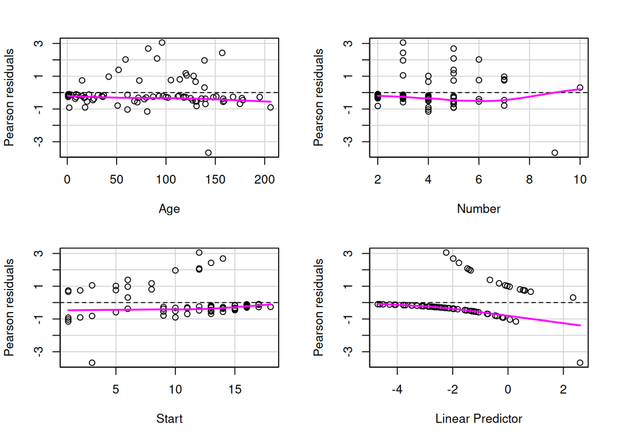

```
       Test stat Pr(>|Test stat|)
Age       6.9522         0.008372 **
Number    1.1359         0.286513
Start     4.4378         0.035152 *
---
Signif. codes:  0 '***' 0.001 '**' 0.01 '*' 0.05 '.' 0.1 ' ' 1
```

```r
library(car)
residualPlots(glm_fit)
```

Como se explica en la [ayuda de R del gráfico binnedplot](https://www.rdocumentation.org/packages/arm/versions/1.14-4/topics/binnedplot):  
In logistic regression, as with linear regression, the residuals can be defined as observed minus expected values. The data are discrete and so are the residuals. As a result, plots of raw residuals from logistic regression are generally not useful. The binned residuals plot instead, after dividing the data into categories (bins) based on their fitted values, plots the average residual versus the average fitted value for each bin.

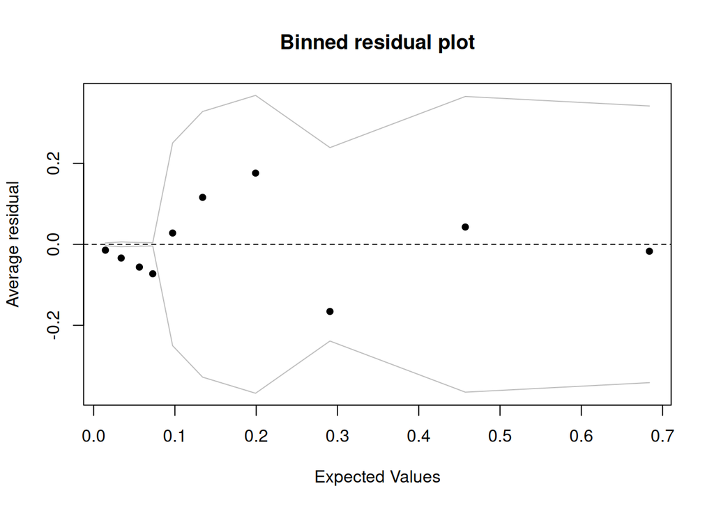

```r
library(arm)
binnedplot(fitted(glm_fit),
           residuals(glm_fit,type = 'response'),
           nclass = NULL,
           xlab = "Expected Values",
           ylab = "Average residual",
           main = "Binned residual plot")
```

### Categorización de variables

Hemos tratado la variable Start y la variable Number como continuas pero quizás no sea lo mejor puesto que también pueden verse como variables categóricas (Number sería claramente ordinal). Así, vamos a categorizarlas y a obtener el modelo de regresión logística con ellas. Lo adecuado en estas circunstancias es seguir las instrucciones del experto en el dominio que nos indicará la manera correcta de categorizar las variables. Para este ejemplo, estudiaremos con más detalle las variables para decidir la categorización a realizar.

```r
table(kyphosis$Number)
```

```
 2  3  4  5  6  7  9 10
12 23 18 17  4  5  1  1
```

En el caso de Number vamos a categorizar del siguiente modo: 4 o menos vs 5 más.

```r
kyphosis$Number_cat = cut(kyphosis$Number,breaks = c(0,4,10))
```

Analicemos cómo se relaciona con el target:

```r
table(kyphosis$Number_cat,kyphosis$Kyphosis)
```

```
         absent present
  (0,4]      47       6
  (4,10]     17      11
```

```r
chisq.test(kyphosis$Number_cat,kyphosis$Kyphosis)
```

```
    Pearson's Chi-squared test with Yates' continuity correction

data:  kyphosis$Number_cat and kyphosis$Kyphosis
X-squared = 7.036, df = 1, p-value = 0.007989
```

```r
table(kyphosis$Start)
```

```
 1  2  3  5  6  8  9 10 11 12 13 14 15 16 17 18
 5  2  3  3  4  2  4  4  3  5 12  5  7 17  4  1
```

En el caso de Start vamos a categorizar del siguiente modo: $\{1,2,3,4,5,6\}, \{7,8,9,10,11,12\},\{13,14,15,16,17,18\}$.

```r
kyphosis$Start_cat = cut(kyphosis$Start,breaks = c(0,6,12,18))
```

```r
table(kyphosis$Start_cat,kyphosis$Kyphosis)
```

```
          absent present
  (0,6]        8       9
  (6,12]      12       6
  (12,18]     44       2
```

```r
chisq.test(kyphosis$Start_cat,kyphosis$Kyphosis)
```

```
    Pearson's Chi-squared test

data:  kyphosis$Start_cat and kyphosis$Kyphosis
X-squared = 19.802, df = 2, p-value = 5.012e-05
```

```r
# reordenamos los niveles
kyphosis$Start_cat <- factor(kyphosis$Start_cat, levels=c('(12,18]', '(6,12]', '(0,6]'))
```

Hagamos ahora el modelo de regresión logística con las variables categorizadas:

```r
glm_cat <- glm(Kyphosis~Age+Number_cat+Start_cat, family=binomial("logit"),data=kyphosis)
summary(glm_cat)
```

```
Call:
glm(formula = Kyphosis ~ Age + Number_cat + Start_cat, family = binomial("logit"),
    data = kyphosis)

Coefficients:
                 Estimate Std. Error z value Pr(>|z|)
(Intercept)      -5.30542    1.33526  -3.973 7.09e-05 ***
Age               0.01472    0.00731   2.013 0.044091 *
Number_cat(4,10]  1.59350    0.72697   2.192 0.028382 *
Start_cat(6,12]   2.50297    0.95552   2.619 0.008806 **
Start_cat(0,6]    3.46813    0.98596   3.518 0.000436 ***
---
Signif. codes:  0 '***' 0.001 '**' 0.01 '*' 0.05 '.' 0.1 ' ' 1

(Dispersion parameter for binomial family taken to be 1)

    Null deviance: 83.234  on 80  degrees of freedom
Residual deviance: 54.190  on 76  degrees of freedom
AIC: 64.19

Number of Fisher Scoring iterations: 6
```

Calculemos las predicciones:

```r
preds_cat = predict(glm_cat,kyphosis,type='response')
preds_bin_cat <- factor(ifelse(preds_cat > 0.5, 'present', 'absent'))
confusionMatrix(preds_bin_cat,kyphosis$Kyphosis,positive = 'present',mode='everything')
```

```
Confusion Matrix and Statistics

          Reference
Prediction absent present
   absent      59       7
   present      5      10

               Accuracy : 0.8519
                 95% CI : (0.7555, 0.921)
    No Information Rate : 0.7901
    P-Value [Acc > NIR] : 0.1067

                  Kappa : 0.5331

 Mcnemar's Test P-Value : 0.7728

            Sensitivity : 0.5882
            Specificity : 0.9219
         Pos Pred Value : 0.6667
         Neg Pred Value : 0.8939
              Precision : 0.6667
                 Recall : 0.5882
                     F1 : 0.6250
             Prevalence : 0.2099
         Detection Rate : 0.1235
   Detection Prevalence : 0.1852
      Balanced Accuracy : 0.7551

       'Positive' Class : present
```

**Pregunta:**  
¿Qué modelo seleccionarías?

Analicemos ahora los odds ratio:

```r
# Obtener los coeficientes del modelo
coefs_cat <- coef(glm_cat)

# Calcular los odds ratios
odds_ratios_cat <- exp(coefs_cat)
odds_ratios_cat[2:5]
```

```
             Age Number_cat(4,10]  Start_cat(6,12]   Start_cat(0,6]
        1.014825         4.920936        12.218672        32.076547
```

**Pregunta:**  
¿Cómo interpretarías estos odds ratio?

### Modelo con interacción

```r
glm_cat2 <- glm(Kyphosis~Age+Number_cat*Start_cat, family=binomial("logit"),data=kyphosis)
summary(glm_cat2)
```

```
Call:
glm(formula = Kyphosis ~ Age + Number_cat * Start_cat, family = binomial("logit"),
    data = kyphosis)

Coefficients:
                                  Estimate Std. Error z value Pr(>|z|)
(Intercept)                      -5.214689   1.428494  -3.650 0.000262 ***
Age                               0.014916   0.007415   2.012 0.044266 *
Number_cat(4,10]                  1.361385   1.489188   0.914 0.360622
Start_cat(6,12]                   2.405592   1.347345   1.785 0.074191 .
Start_cat(0,6]                    3.285009   1.300294   2.526 0.011525 *
Number_cat(4,10]:Start_cat(6,12]  0.210676   1.870203   0.113 0.910309
Number_cat(4,10]:Start_cat(0,6]   0.384034   1.841660   0.209 0.834818
---
Signif. codes:  0 '***' 0.001 '**' 0.01 '*' 0.05 '.' 0.1 ' ' 1

(Dispersion parameter for binomial family taken to be 1)

    Null deviance: 83.234  on 80  degrees of freedom
Residual deviance: 54.146  on 74  degrees of freedom
AIC: 68.146

Number of Fisher Scoring iterations: 6
```

Claramente la interacción es no significativa y empeora el modelo.